# L15

# Inference

- Calculating some useful quantity from a joint probability distribution

## Inference by Enumeration

- Given evidence variables $E_{1}{\dots}E_{k}=e_{1}{\dots}e_{k}$, Query* variables $Q$ and hidden variables $H_{1},{\dots}H_{r}$, find $\mathbb{P}(Q|e_{1}{\dots}e_{k})$
- Steps:
  1. Select the entries consistent with the evidence
  2. Sum out $H$ to get joint of $Q$ and $E$
  3. Normalize (multiply by $\frac{1}{Z}$)
- Given unlimited time, inference in BN is easy
- Issue: may not necessarily be directly represented in the BN
  - Computation on the BN can answer the more complicated query
- Note: $\mathbb{P}(B|+j,+m)\propto_{B}\mathbb{P}(B,+j,+m)$
  - $\mathbb{P}(B,+j,+m)=\sum_{e,a}\mathbb{P}(B,e,a,+j,+m)$
  - With bayes net reconstitution formula, we can find it equal to $\sum_{e,a}\mathbb{P}(B)\mathbb{P}(e)\mathbb{P}(a|B,e)\mathbb{P}(+j|a)\mathbb{P}(+m|a)$
- Slow because you join up the whole joint distribution before you sum out the hidden variables

## Variable Elimination (VE)

- Idea: interleave joining and marginalizing
- Can multiply parts of the BN together to get factors
- Example:
- Variables
  - $R$ ≙ raining?
  - $T$ ≙ traffic?
  - $L$ ≙ late for class?
- $\sum_{t}\sum_{r}\mathbb{P}(L|t)\mathbb{P}(r)\mathbb{P}(t|r)$
- Implementation: join only until it is possible to eliminate, then eliminate
  - Keep track of a list of factors (initialized as the list of nodes in the BN)
  - When there is only one table with a variable, sum out the variable
    - Note: this always happens when you join on a variable
- Alg:
  1. If evidence, start with factors that select that evidence
  2. While there are still hidden variables (not $Q$ or evidence)
     1. Pick a hidden variable $h$
     2. Join all factors mentioning $H$
     3. Eliminate (sum out) $H$
  3. Join all remaining factors
  4. Normalize
- eg:

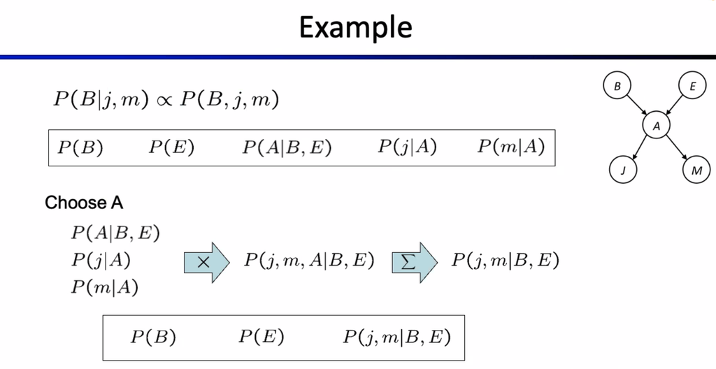

  - Factors for each step are boxed

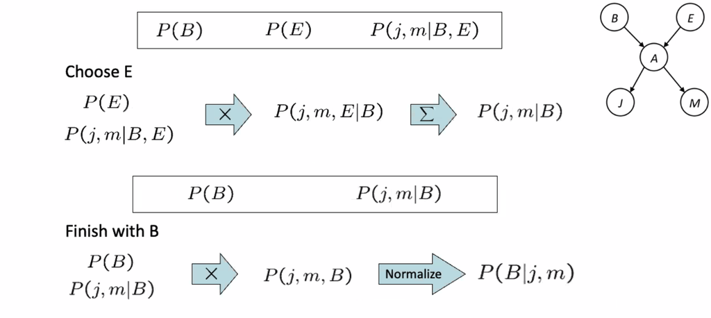

#### Operations

##### Joins

- Combine like factors (multiply their probs)
- Just like a db join
- Get all factors over the joining variable
- Build a new factor over the union of the variables involved
- Joining on a variable ≙ join all tables with that variable
- Multiple joins ≙ you have to do a pointwise multiplication
  - You add variables that are necessary to describe all of the rows of all of the joined tables

#### Marginalization (Elimination)

- Take a factor and sum out a variable
- Shrinks a factor to a smaller one
- Type of ‘projection’ operation
- Sum values over rows that differ in the variable being eliminated